# Section 9

Guadalupe Tuñón

March 16, 2016

# Today

- The bootstrap
- Fixed effects

# Bootstrapping

- So far, we have covered methods for hypothesis testing that require information about the population distribution and/or we rely on approximations to the normal curve for the sampling distributions of sample means or sums (there is one exception for this, what is it?)
- But sometimes we don’t know what the population looks like or we cannot rely on the central limit theorem to construct confidence intervals.
- In such settings, we use the bootstrap—we approximate the population distribution by using the information in the sample.

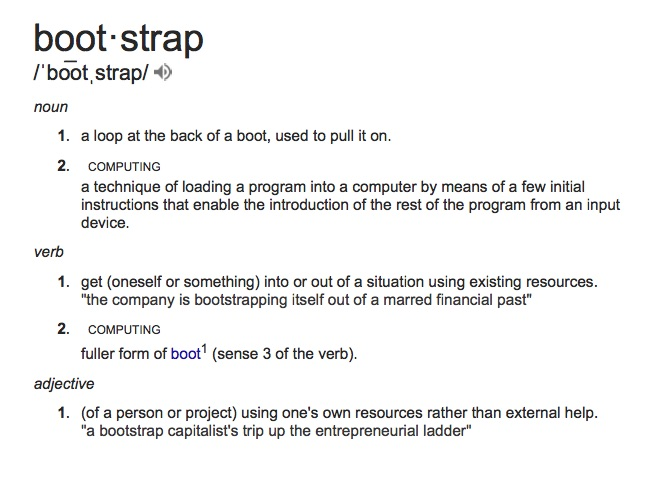

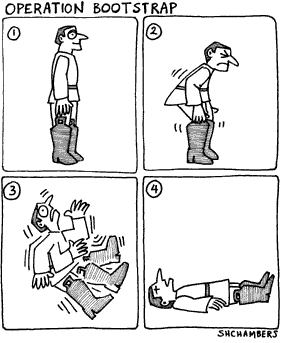

- Bootstrap resampling is a methodology for approximating the sampling distribution of an estimator of interest.
- The population distribution is approximated by the empirical sample—which we then take as a `bootstrap population’ from which we resample.
- We draw samples with replacement from the bootstrap population (i.e., the original empirical sample and, for each simulated sample, store the statistic of interest.
- The histogram of these statistics estimates the sampling distribution of the estimator.
- The SD of the simulation statistics estimates the SE of the estimator.
- Key to success is that the bootstrap resampling correctly mimics the original sampling procedure.

# Bootstrap (mean)

Say we collected the following simple random sample from a very large population–so that we could treat the sample as i.i.d. draws from that large population.

```r
# Some data
z=c(1,6,3,3,4,4)
```

How can we use the bootstrap to build a confidence interval for the sample mean?

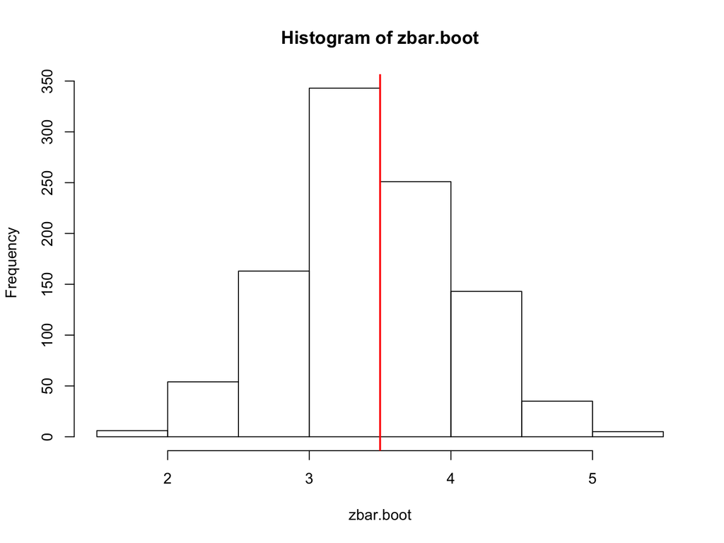

```r
## Bootstrap CI for mean of z
B=1000
zbar.boot=rep(NA,B)
for(i in 1:B){
    z.boot=sample(z,replace=TRUE)
    zbar.boot[i]=mean(z.boot)
}

hist(zbar.boot)
abline(v=mean(z), col="red", lwd=2)
```

```r
## CI of means
quantile(zbar.boot,c(.025,.975))
```

```
##     2.5%    97.5%
## 2.333333 4.666667
```

But we know the sample mean and its sampling distribution well. The usefulness of the bootstrap is more clearly illustrated with a statistic we know less about (and for which we don’t know the analytical formula for the SE).

*The trimmed mean.* A trimmed mean is a method of averaging that removes a small percentage/number of the largest and smallest values before calculating the mean. After removing the specified observations, the trimmed mean is found using an arithmetic averaging formula.

A function to compute a trimmed mean:

```r
trimmed.mean <- function(x,k){
    ## get order statistics
    x.ord=sort(x)
    ## remove k outliers on each end
    n=length(x)
    x.trimmed=x.ord[(k+1):(n-k)]
    ## get trimmed mean
    mean(x.trimmed)
}

# Remember z
z
```

```
## [1] 1 6 3 3 4 4
```

```r
trimmed.mean(z, k=1)
```

```
## [1] 3.5
```

```r
trimmed.mean(z, k=2)
```

```
## [1] 3.5
```

# Bootstrap (trimmed mean)

*Goal: estimate sampling distribution and 95% CI for trimmed mean with k=3.*

k=3 means that once we obtain the sample, we will discard the 3 highest and 3 lowest values before taking the mean.

We will work with a new sample, which we know is a simple random sample of a population.

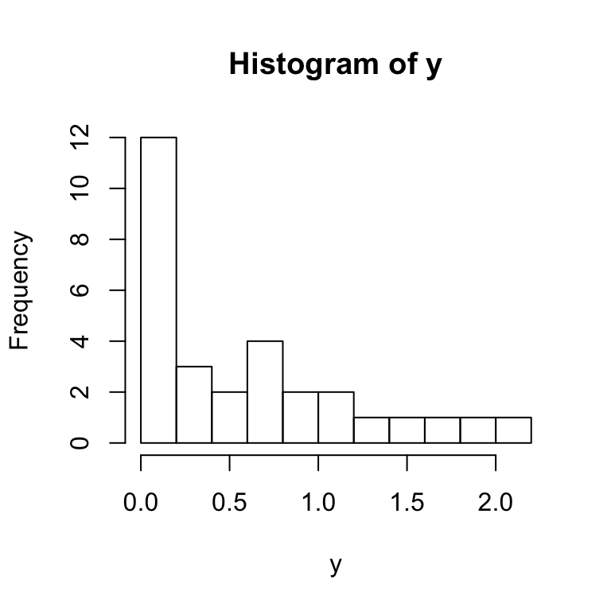

```r
## data:

y <- c(1.226593, 0.03184055, 0.6407651 ,0.2145773, 2.171472,
       0.3978129, 0.5184024, 0.7989738, 1.465239, 0.1920495,
       1.055561, 0.8558294, 1.865417, 1.035092, 1.662674,
       0.1127212, 0.08101172, 0.1745952, 0.1075828, 0.03026473,
       0.09133911, 0.2252703, 0.4696279, 0.6739304, 0.8217542,
       0.1027049, 0.0130761, 0.1659805, 0.6633236, 0.05633055)

hist(y, breaks=10)
```

# The bootstrap

```r
B <- 10000
k <- 3
boot <- rep(NA, B)

for(b in 1:B){

    ## Generate a bootstrap sample by
    ## resampling from y with replacement
    y.boot <- sample(y,replace=TRUE)

    ## compute the trimmed mean from bootstrap sample
    boot[b] <- trimmed.mean(y.boot, k)
}
```

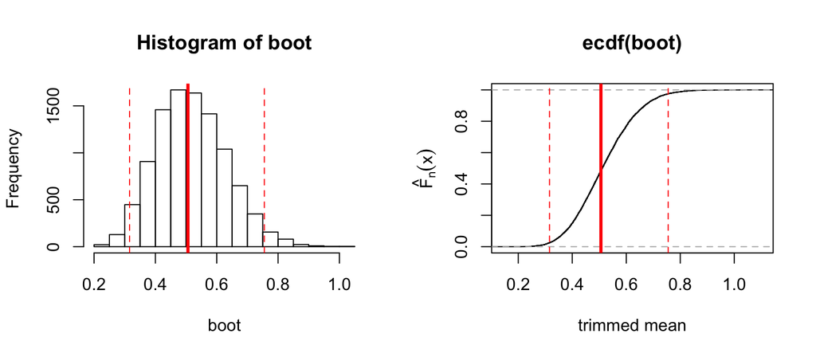

```r
## plot histogram and empirical cdf
par(mfrow=c(1,2))
hist(boot,breaks=20)
abline(v=sample_trimmedmean, col="red",lwd=3)
abline(v=quantile(boot,c(.025,.975)),col="red", lty=2) #CI

plot(ecdf(boot), xlab="trimmed mean", ylab="")
mtext(text = expression(hat(F)[n](x)), side = 2, line = 2.5)
abline(v=sample_trimmedmean, col="red",lwd=3)
abline(v=quantile(boot,c(.025,.975)),col="red", lty=2) #CI
```

How do we estimate the SE of our observed trimmed mean?

```r
#SE
sd(boot)
```

```
## [1] 0.113859
```

**We can even bootstrap a correlation…**

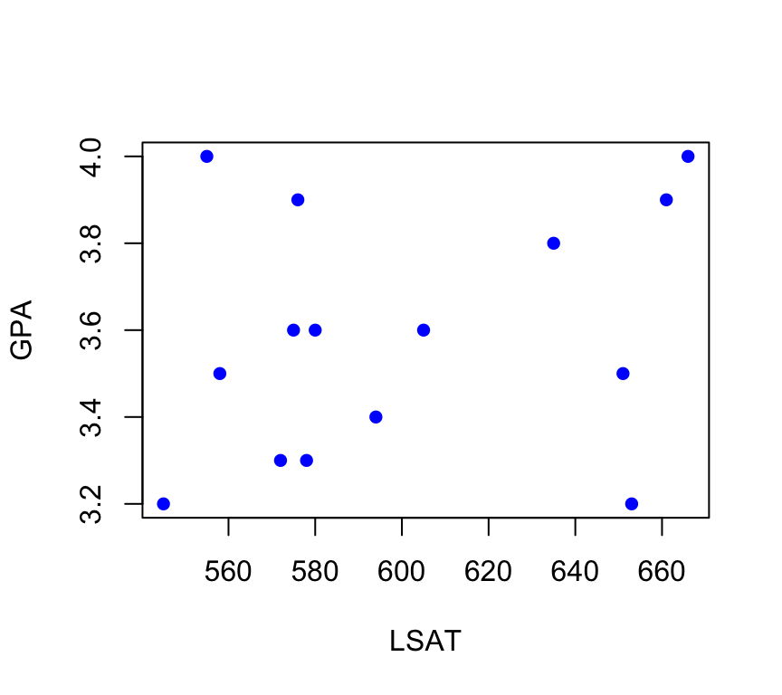

```r
LSAT <- c(576,635,578,558,666,580,555,651,661,605,575,653,545,572,594)
GPA <- c(3.9,3.8,3.3,3.5,4.0,3.6,4.0,3.5,3.9,3.6,3.6,3.2,3.2,3.3,3.4)

par(mfrow=c(1,1))
plot(LSAT,GPA, pch=16, col="blue")
```

```r
## calculate empirical correlation of the data
r.hat <- cor(LSAT,GPA)
r.hat
```

```
## [1] 0.2603757
```

- We can use the bootstrap to estimate the CI of the correlation.
- Key point: we are assuming the data were i.i.d. draws (as pairs) from an underlying population.

```r
## bootstrap
B <- 10000
n <- length(LSAT)
r.boot <- rep(NA,B)

for(b in 1:B){
    ## resample indices (to keep GPA,LSAT pairs together)
    idx.boot <- sample(1:n,replace=TRUE)

    ## get resampled LSAT and GPA:
    LSAT.boot <- LSAT[idx.boot]
    GPA.boot <- GPA[idx.boot]

    ## calculate correlation of bootstrap sample
    r.boot[b] <- cor(LSAT.boot,GPA.boot)
}
```

```r
hist(r.boot)
abline(v=r.hat,col="red",lwd=3)

## 95% Bootstrap CI
quantile(r.boot,c(.025,.975))
```

```
##       2.5%      97.5%
## -0.3768194  0.7930448
```

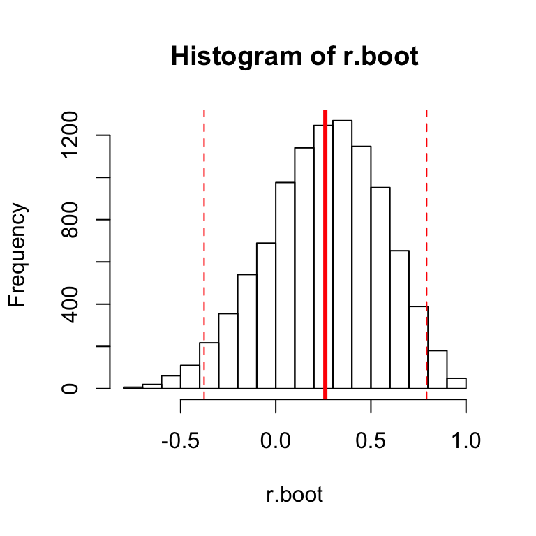

```r
abline(v=quantile(r.boot,c(.025,.975)),col="red", lty=2)
```

# Bootstrapping a regression model

We will use the `swiss` dataset to run a regression of `education` on `infant mortality`. We will then use the bootstrap to estimate $SE(\hat{\beta})$. Note that to use the bootstrap we need to assume a model (for the sake of the exercise, we will believe this assumption despite it is not very credible in this context).

$Education_{i} = \alpha + \beta * IM_{i} + \epsilon_{i}$

```r
ols <- lm(Education ~ Infant.Mortality, data=swiss)
ols
```

```
##
## Call:
## lm(formula = Education ~ Infant.Mortality, data = swiss)
##
## Coefficients:
##      (Intercept)  Infant.Mortality
##          17.5175           -0.3279
```

```r
beta_hat <- lm(Education ~ Infant.Mortality, data=swiss)$coefficients[2]
beta_hat
```

```
## Infant.Mortality
##       -0.3278817
```

```r
yhat <- ols$fitted
e <- ols$residuals
```

What is the mean of the residuals?

```r
mean(e)
```

```
## [1] -6.63624e-17
```

Why is mean zero e important given the OLS model?

What is the variance of the residuals?

```r
mean((e-mean(e))^2)
```

```
## [1] 89.59625
```

Why shouldn’t we use n-1 in the denominator to calculate this variance?

We will now use the bootstrap to estimate $SE(\hat{\beta})$.

```r
betaboot <- rep(NA,B)

for(b in 1:B){
    ## resample from the vector of residuals
    Y_Star <- yhat + sample(e, replace=TRUE)

    ## calculate beta hat of bootstrap sample
    betaboot[b] <- lm(Y_Star ~ swiss$Infant.Mortality)$coefficients[2]
}
```

```r
hist(betaboot)
abline(v=beta_hat, col="red", lwd=3)

## 95% Bootstrap CI
quantile(betaboot, c(.025,.975))
```

```
##      2.5%     97.5%
## -1.326732  0.594622
```

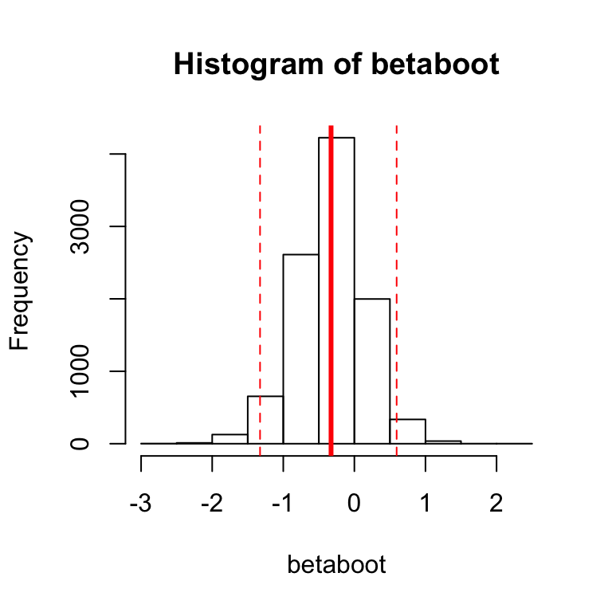

```r
abline(v=quantile(betaboot,c(.025,.975)), col="red", lty=2)
```

We can also compare the bootstrap SE to the $SE(\hat{\beta})$ from OLS.

```r
sd(betaboot)
```

```
## [1] 0.4797294
```

```r
summary(ols)
```

```
##
## Call:
## lm(formula = Education ~ Infant.Mortality, data = swiss)
##
## Residuals:
##     Min      1Q  Median      3Q     Max
## -10.567  -5.091  -2.140   1.548  41.384
##
## Coefficients:
##                  Estimate Std. Error t value Pr(>|t|)
## (Intercept)       17.5175     9.8669   1.775   0.0826 .
## Infant.Mortality  -0.3279     0.4897  -0.670   0.5065
## ---
## Signif. codes:  0 '***' 0.001 '**' 0.01 '*' 0.05 '.' 0.1 ' ' 1
##
## Residual standard error: 9.674 on 45 degrees of freedom
## Multiple R-squared:  0.009865,   Adjusted R-squared:  -0.01214
## F-statistic: 0.4483 on 1 and 45 DF,  p-value: 0.5065
```

# Panel data

Panel data (also known as longitudinal or cross sectional time-series data) is a data set in which the behavior of entities are observed across time. These entities could be states, companies, individuals, countries, etc.

```r
head(country_data)
```

```
##   country year           y        x1
## 1       A 1990  1342787840 0.2779036
## 2       A 1991 -1899660544 0.3206847
## 3       A 1992   -11234363 0.3634657
## 4       A 1993  2645775360 0.2461440
## 5       A 1994  3008334848 0.4246230
## 6       A 1995  3229574144 0.4772141
```

For this exercise, we will focus on the heterogeneity acroos countries:

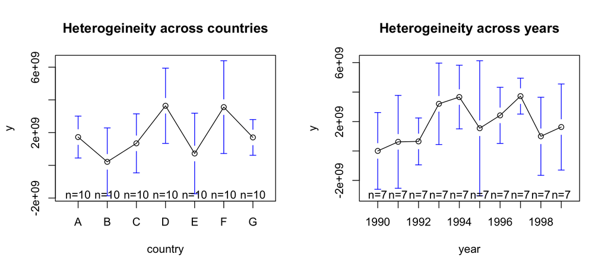

```r
par(mfrow=c(1,2))
plotmeans(y ~ country, main="Heterogeineity across countries", data=country_data)
plotmeans(y ~ year, main="Heterogeineity across years", data=country_data)
```

Regular OLS does not consider heterogeneity across groups or time…

```r
ols <-lm(y ~ x1, data=country_data)
summary(ols)
```

```
##
## Call:
## lm(formula = y ~ x1, data = country_data)
##
## Residuals:
##        Min         1Q     Median         3Q        Max
## -9.546e+09 -1.578e+09  1.554e+08  1.422e+09  7.183e+09
##
## Coefficients:
##              Estimate Std. Error t value Pr(>|t|)
## (Intercept) 1.524e+09  6.211e+08   2.454   0.0167 *
## x1          4.950e+08  7.789e+08   0.636   0.5272
## ---
## Signif. codes:  0 '***' 0.001 '**' 0.01 '*' 0.05 '.' 0.1 ' ' 1
##
## Residual standard error: 3.028e+09 on 68 degrees of freedom
## Multiple R-squared:  0.005905,   Adjusted R-squared:  -0.008714
## F-statistic: 0.4039 on 1 and 68 DF,  p-value: 0.5272
```

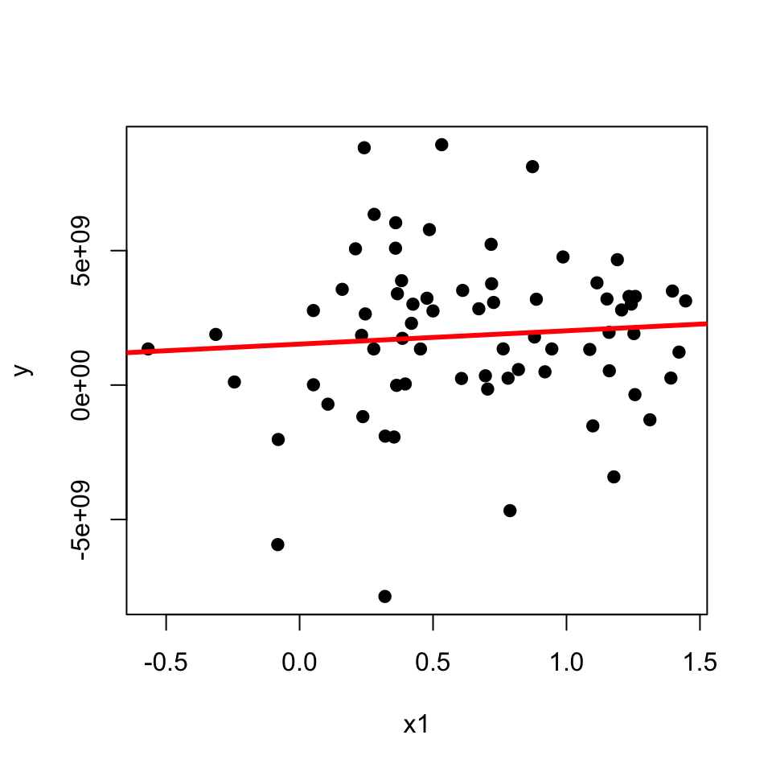

```r
par(mfrow=c(1,1))
plot(country_data$x1, country_data$y, pch=19, xlab="x1", ylab="y")
abline(lm(country_data$y~country_data$x1),lwd=3, col="red")
```

# Fixed effects

Fixed-effects models help to isolate the effects of within-unit variation—though coefficients are pooled across units.

$Y_{it}= \alpha_i + \beta D_{it} + \epsilon_{it}$ where there is one dummy variable (``fixed effect“) $\alpha_i$ for each unit $i$ (here unit=country). This fixed-effect is a unit-specific intercept.

How will the design matrix look here?

```r
fixed.dum <-lm(y ~ x1 + factor(country) - 1, data=country_data)
summary(fixed.dum)
```

```
##
## Call:
## lm(formula = y ~ x1 + factor(country) - 1, data = country_data)
##
## Residuals:
##        Min         1Q     Median         3Q        Max
## -8.634e+09 -9.697e+08  5.405e+08  1.386e+09  5.612e+09
##
## Coefficients:
##                    Estimate Std. Error t value Pr(>|t|)
## x1                2.476e+09  1.107e+09   2.237  0.02889 *
## factor(country)A  8.805e+08  9.618e+08   0.916  0.36347
## factor(country)B -1.058e+09  1.051e+09  -1.006  0.31811
## factor(country)C -1.723e+09  1.632e+09  -1.056  0.29508
## factor(country)D  3.163e+09  9.095e+08   3.478  0.00093 ***
## factor(country)E -6.026e+08  1.064e+09  -0.566  0.57329
## factor(country)F  2.011e+09  1.123e+09   1.791  0.07821 .
## factor(country)G -9.847e+08  1.493e+09  -0.660  0.51190
## ---
## Signif. codes:  0 '***' 0.001 '**' 0.01 '*' 0.05 '.' 0.1 ' ' 1
##
## Residual standard error: 2.796e+09 on 62 degrees of freedom
## Multiple R-squared:  0.4402, Adjusted R-squared:  0.368
## F-statistic: 6.095 on 8 and 62 DF,  p-value: 8.892e-06
```

Each component of the factor variable (country) is absorbing the variation particular to each country.

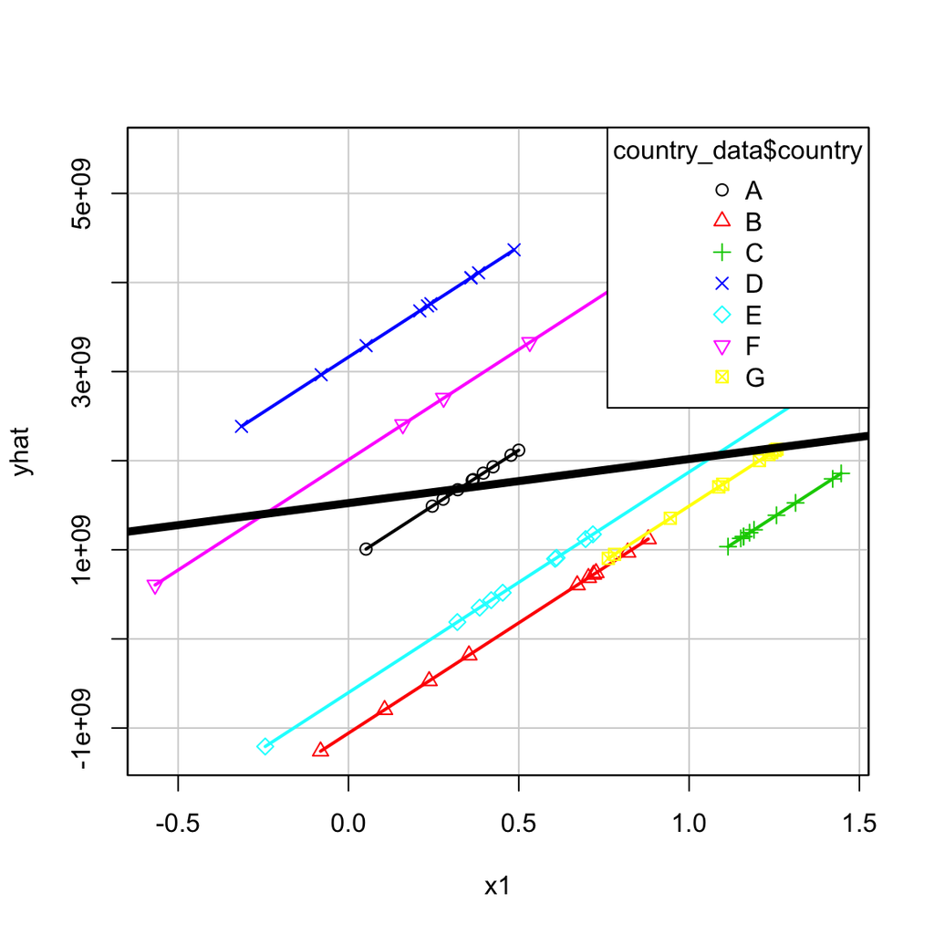

```r
yhat <- fixed.dum$fitted
scatterplot(yhat~country_data$x1|country_data$country,
            xlab="x1", ylab="yhat", legend.coords="topright")
abline(lm(country_data$y~country_data$x1), lwd=5, col="black")
```